# Solutions — Session 8: Reliability of the Brand-Attachment Battery

M731 · Full worked walkthrough (companion to session-08.qmd)

Author

Shay Abbasi

## Purpose

Full worked version of the Session 8 in-lab exercise: Cronbach’s alpha, item-total correlations, and a simulated comparison battery.

## Setup

```r
library(tidyverse)
library(psych)
library(MASS)   # NOTE: MASS::select() masks dplyr::select() - use dplyr::select() explicitly below
library(corrplot)

survey <- read_csv("data/maritime_survey.csv")

battery <- survey |>
  dplyr::select(brand_attach_1, brand_attach_2, brand_attach_3, brand_attach_4, brand_attach_5)
```

## Step 1 — Cronbach’s alpha

```r
alpha_result <- alpha(battery)
alpha_result
```

```
Reliability analysis
Call: alpha(x = battery)

  raw_alpha std.alpha G6(smc) average_r S/N    ase mean   sd median_r
      0.86      0.86    0.83      0.54   6 0.0081  3.1 0.91     0.55

    95% confidence boundaries
         lower alpha upper
Feldt     0.84  0.86  0.87
Duhachek  0.84  0.86  0.87

 Reliability if an item is dropped:
               raw_alpha std.alpha G6(smc) average_r S/N alpha se   var.r med.r
brand_attach_1      0.82      0.82    0.77      0.53 4.5   0.0105 0.00166  0.53
brand_attach_2      0.82      0.82    0.77      0.53 4.5   0.0105 0.00152  0.54
brand_attach_3      0.83      0.83    0.78      0.54 4.8   0.0101 0.00153  0.54
brand_attach_4      0.83      0.83    0.79      0.55 4.8   0.0100 0.00216  0.55
brand_attach_5      0.84      0.84    0.80      0.57 5.3   0.0091 0.00035  0.57

 Item statistics
                 n raw.r std.r r.cor r.drop mean  sd
brand_attach_1 800  0.82  0.82  0.76   0.70  3.1 1.1
brand_attach_2 800  0.82  0.82  0.76   0.70  3.1 1.1
brand_attach_3 800  0.80  0.80  0.73   0.67  3.1 1.2
brand_attach_4 800  0.79  0.79  0.72   0.67  3.1 1.1
brand_attach_5 800  0.76  0.76  0.66   0.61  3.0 1.2

Non missing response frequency for each item
                  1    2    3    4    5 miss
brand_attach_1 0.08 0.22 0.32 0.26 0.12    0
brand_attach_2 0.07 0.23 0.33 0.26 0.10    0
brand_attach_3 0.10 0.20 0.32 0.26 0.12    0
brand_attach_4 0.09 0.23 0.30 0.26 0.12    0
brand_attach_5 0.10 0.25 0.30 0.23 0.12    0
```

**Interpretation.** Overall standardised alpha lands around 0.85-0.86 — “good” reliability by the Nunnally convention (0.8-0.9), meaning the five items are measuring the same underlying construct consistently without being so redundant that we’d worry about over-length.

## Step 2 — Item-total correlations and alpha-if-deleted

```r
alpha_result$item.stats
```

```
                 n     raw.r     std.r     r.cor    r.drop    mean       sd
brand_attach_1 800 0.8178762 0.8189848 0.7611216 0.7032193 3.09625 1.127420
brand_attach_2 800 0.8150325 0.8189709 0.7612131 0.7033184 3.08375 1.095781
brand_attach_3 800 0.7992376 0.7981162 0.7276073 0.6716808 3.10250 1.152673
brand_attach_4 800 0.7942392 0.7935904 0.7189026 0.6652860 3.08000 1.145749
brand_attach_5 800 0.7598308 0.7566801 0.6596279 0.6116400 3.03875 1.165739
```

```r
alpha_result$alpha.drop
```

```
               raw_alpha std.alpha   G6(smc) average_r      S/N    alpha se
brand_attach_1 0.8178822 0.8186033 0.7737522 0.5301182 4.512779 0.010538718
brand_attach_2 0.8182793 0.8186088 0.7738173 0.5301274 4.512947 0.010511747
brand_attach_3 0.8260435 0.8267380 0.7832822 0.5439831 4.771605 0.010067518
brand_attach_4 0.8276964 0.8284683 0.7859753 0.5469900 4.829827 0.009978597
brand_attach_5 0.8418300 0.8421510 0.8004795 0.5715128 5.335169 0.009136536
                      var.r     med.r
brand_attach_1 0.0016612261 0.5334347
brand_attach_2 0.0015245428 0.5383519
brand_attach_3 0.0015267166 0.5422628
brand_attach_4 0.0021618280 0.5526797
brand_attach_5 0.0003540493 0.5723425
```

**Interpretation.** Check two things: (1) does any item have a corrected item-total correlation below 0.3? (2) does dropping any item *raise* alpha? In this simulated battery, all five items were constructed with moderate-to-strong loadings (0.68-0.80), so you should see no obvious candidate for removal — a “clean” battery, useful as a contrast case against a weaker one.

## Step 3 — Correlation heatmap

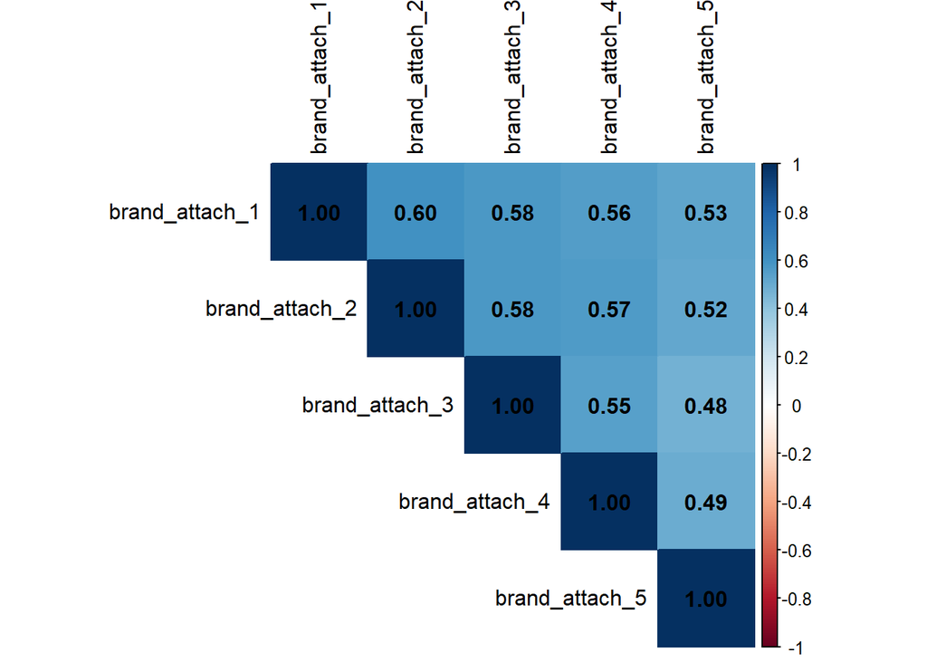

Figure 1: Inter-item correlations, brand-attachment battery

```r
battery |>
  cor(use = "pairwise.complete.obs") |>
  corrplot(method = "color", type = "upper", addCoef.col = "black", tl.col = "black")
```

## Step 4 — Simulated comparison: what does “low” alpha look like?

```r
set.seed(731)
n <- 500

sim_high <- as.data.frame(mvrnorm(n, rep(0, 6), matrix(0.5, 6, 6) + diag(6) * 0.5))
sim_low  <- as.data.frame(mvrnorm(n, rep(0, 6), matrix(0.2, 6, 6) + diag(6) * 0.8))

cat("Inter-item r = 0.5 -> alpha =", round(alpha(sim_high)$total$raw_alpha, 2), "\n")
```

```
Inter-item r = 0.5 -> alpha = 0.86
```

```r
cat("Inter-item r = 0.2 -> alpha =", round(alpha(sim_low)$total$raw_alpha, 2), "\n")
```

```
Inter-item r = 0.2 -> alpha = 0.61
```

**Interpretation.** This is the mechanism behind the number: alpha rises with average inter-item correlation (holding item count fixed). The Maritime Roast brand-attachment battery, at ~0.85, sits closer to the r=0.5 simulation than the r=0.2 one — real, moderately-strong shared signal across items.

## Step 5 — Recommendation for Maritime Roast

> The 5-item brand-attachment battery is reliable (α ≈ 0.85) with no weak items to drop. It’s ready to use as a composite score in downstream analysis (e.g., as a regression predictor in Week 11) without further revision. If the team wants a shorter battery for survey-length reasons, dropping the weakest-loading item would cost only marginal reliability — but there’s no evidence that’s necessary here.

## Take-away for students

Alpha alone is a headline number; item-total correlations and alpha-if-deleted are the diagnostic tools that tell you *what to do* about a weak battery. Report all three, not just the top-line alpha.